# When do Janzen–Connell effects matter? A phylogenetic meta‐analysis of conspecific negative distance and density dependence experiments - Song - 2021 - Ecology Letters - Wiley Online Library

[Ecology Letters](https://onlinelibrary.wiley.com/journal/14610248)

[Volume 24, Issue 3](https://onlinelibrary.wiley.com/toc/14610248/2021/24/3) p. 608-620

[figure not shown]

Review And Synthesis

Free Access

# When do Janzen–Connell effects matter? A phylogenetic meta-analysis of conspecific negative distance and density dependence experiments

[Xiaoyang Song](https://onlinelibrary.wiley.com/action/doSearch?ContribAuthorStored=Song%2C+Xiaoyang),

These authors contributed equally to this work.

[Jun Ying Lim](https://onlinelibrary.wiley.com/action/doSearch?ContribAuthorStored=Lim%2C+Jun+Ying),

[Jie Yang](https://onlinelibrary.wiley.com/action/doSearch?ContribAuthorStored=Yang%2C+Jie),

[Matthew Scott Luskin](https://onlinelibrary.wiley.com/action/doSearch?ContribAuthorStored=Luskin%2C+Matthew+Scott),

These authors contributed equally to this work.

First published: 31 December 2020

https://doi.org/10.1111/ele.13665

Citations: 3

## Abstract

The Janzen–Connell (J-C) hypothesis suggests that specialised natural enemies cause distance- or density-dependent mortality among host plants and is regarded as an important mechanism for species coexistence. However, there remains debate about whether this phenomenon is widespread and how variation is structured across taxa and life stages. We performed the largest meta-analysis of experimental studies conducted under natural settings to date. We found little evidence of distance-dependent or density-dependent mortality when grouping all types of manipulations. Our analysis also reveals very large variation in response among species, with 38.5% of species even showing positive responses to manipulations. However, we found a strong signal of distance-dependent mortality among seedlings but not seed experiments, which we attribute to (a) seedlings sharing susceptible tissues with adults (leaves, wood, roots), (b) seedling enemies having worse dispersal than seed enemies and (c) seedlings having fewer physical and chemical defences than seeds. Both density- and distance-dependent mortality showed large variation within genera and families, suggesting that J-C effects are not strongly phylogenetically conserved. There were no clear trends with latitude, rainfall or study duration. We conclude that J-C effects may not be as pervasive as widely thought. Understanding the variation in J-C effects provides opportunities for new discoveries that will refine our understanding of J-C effects and its role in species coexistence.

## Introduction

An enduring challenge in community ecology is to understand the mechanisms by which diversity is generated and maintained (Chesson, 2000; Vellend, 2016). Models of coexistence emphasise the role of species in limiting their own populations more than those of heterospecifics (termed ‘stabilising’ mechanisms *sensu* Modern Coexistence Theory; Chesson, 2000; Adler *et al*., 2007; HilleRisLambers *et al*., 2012). Stabilising mechanisms promote species coexistence in communities through conspecific negative density or distance dependent (CNDDD) mortality, a phenomenon where a species’ population growth rate declines as they become more abundant and prevents any given species from dominating a community. CNDDD may be the result of resource competition among conspecifics, but at early life stages, seeds and seedlings have smaller resource requirements (Adler *et al*., 2018). The role of natural enemies has gained more support as a driver of CNDDD at early life stages because the majority of seed and seedling mortality is caused by host-specific natural enemies, predominantly fungal pathogens and herbivorous insects (Terborgh, 2012; Bagchi *et al*., 2014; Forrister *et al*., 2019; Song and Corlett, 2020). Natural enemy populations are expected to increase in response to the abundance of their host plants, so abundant plant species are more likely to suffer from enemies and the probability of a host-specific enemy evolving increases with the host’s population size (Ridley, 1930; Gillett, 1962).

Janzen (1970) and Connell (1971) argued that the effects of host-specific plant enemies can have consequences for spatial patterns of recruitment depending on the natural history of hosts and enemies. Conspecific offspring (seeds, seedlings or saplings) may suffer a higher chance of being colonised by enemies when they are closer to adult or parent plants (causing ‘distance-dependent’ mortality), or when they are aggregated in close proximity to each other (causing ‘density-dependent’ mortality; Terborgh, 2012). This idea, widely referred to as the Janzen–Connell (J-C) hypothesis, could be a sufficient stabilising mechanism by which coexistence with other species may be achieved (Mordecai, 2011; Levi *et al*., 2019), and differences in J-C effects have been suggested to explain large-scale patterns in plant diversity (Lambers *et al*., 2002; Johnson *et al*., 2012). The J-C hypothesis is typically tested by manipulating the densities of seeds and seedlings (via transplanting or thinning), or their distances to adult conspecifics, and then comparing mortality rates between treatments (Carson *et al*., 2008). Such experimental manipulations are important because propagule density and distance to parent tree are highly correlated, so careful manipulations are required disentangle the effects distance and density dependence and they alleviate statistical biases that plague many observational studies due to unequal sample sizes and regression dilution (Detto *et al*., 2019). However, for understandable logistical reasons, most J-C experiments only measure offspring mortality and not the cause, and thus may conflate the effects from enemies and other processes such as competition.

Over the past five decades, the J-C hypothesis has received widespread favour among ecologists for a number of reasons, including its clear logic and support in both observational and experimental studies (Mordecai, 2011; Comita *et al*., 2014). However, other theoretical studies argue that the role of J-C effects in species coexistence may be overstated or contingent on specific conditions that are rare in real communities, such as if there is limited variation in fitness among species (Chisholm and Fung, 2020; May *et al*., 2020). Others argue that the apparent prevalence of CNDDD may have been statistically inflated (Detto *et al*., 2019). Nonetheless, a consistent theme of multi-species studies is that the strength of the effect varies across species (Comita *et al*., 2010; Song and Corlett, 2020), with some studies even showing positive effects from increased density or proximity to adults (Dickie *et al*., 2012; Johnson *et al*., 2012; Zhu *et al*., 2015; Segnitz *et al*., 2020). Therefore, while J-C effects clearly operate for some species at some life stages in some systems, there remains significant debate over the generality and magnitude of J-C effects, especially its role in shaping macro-scale diversity patterns (Dickie *et al*., 2012; Chisholm and Fung, 2018; Hülsmann and Hartig, 2018; Detto *et al*., 2019).

## Variation in Janzen-Connell effects

A variety of abiotic and biotic factors potentially influence the role that natural enemies play in plant offspring mortality, and these mediating factors differ across species, life stages and sites. Explaining the variation in J-C effects may shed light on the ecological and evolutionary pressures that shape coexistence mechanisms. First, the dominant natural enemy guilds (fungi, insects, rodents) vary between sites and among species and each enemy guild has unique effects on seeds and seedlings (Fricke *et al*., 2014; Dylewski *et al*., 2020; Jia *et al*., 2020). The J-C effect emphasises the role of specialist enemies in driving CNDDD, but if generalist enemies also operate in a distance- and density-responsive manner, the same CNDDD patterns may arise (Paine and Beck, 2007; Jia *et al*., 2018). Second, there are intrinsic differences in plant physical defences (e.g. leaf toughness; seed coat and wood density) and chemical defences (e.g. secondary metabolites) that partially mediate their susceptibility to enemies (Dalling *et al*., 2011; Turcotte *et al*., 2014; Jia *et al*., 2020; Descombes *et al*., 2020). Abiotic conditions such as seasonality may drive fluctuations in enemy abundance, and thus in the strength of J-C effects through times (Janzen, 1970; Givnish, 1999; Dyer *et al*., 2007; Schemske *et al*., 2009; Lim *et al*., 2015; Forister *et al*., 2015). Comparatively stable tropical environment conditions could allow longer coevolution of plants and enemies leading to stronger interactions than in temperate areas (Comita, 2017), where clades are often younger with fewer coevolved enemies (Coley and Kursar, 2014; Andresen et al. 2018). Finally, detecting J-C effects in natural settings may be obscured if there are positive distance dependence processes, such as local microhabitat filtering wherein offspring benefit from similar abiotic conditions as nearby adult trees, or beneficial biotic interactions, such as through the inoculation of ectomycorrhizal fungi (Xu *et al*., 2020). Therefore, variation in J-C effects is expected and studies may fail to detect J-C effects if these negative CNDDD effects are weaker than positive effects (Zhu *et al*., 2015, Wu et al. 2016).

## Are Janzen-Connell effects phylogenetically conserved?

Closely related species may experience similar CNDDD responses if they share natural enemies (Liu *et al*., 2012; Paine *et al*., 2012) or share traits that mediate their responses to natural enemies (Losos, 2008; Wiens *et al*., 2010, Lebrija-Trejos *et al.,* 2014). The resulting prediction is that species in pathogen-prone clades may experience J-C effects to a similar degree. For example shade-tolerant plants may be more susceptible to fungal pathogens (Jia *et al*., 2020) and genera or families that are predominantly shade-tolerant may thus share a similar degree of susceptibilities to fungal pathogens. Thus, a phylogenetic signal in J-C effects may depend on (1) whether plant species susceptibility to enemies is phylogenetically conserved (including plant defences), and (2) whether enemies host-specificity is phylogenetically conserved (Crawford *et al*., 2019). The phylogenetic scale at which both these processes operate will ultimately shape if J-C effects are conserved at the species-, genus- or family-level (Graham, Storch and Machac, 2017).

Alternatively, J-C effects may vary strongly even among closely related species if evolutionary feedbacks between species and their herbivores has driven diversification within the clade (Kursar *et al*., 2009). For chemical defensives, there are studies reporting significant phylogenetic conservatism (Sedio *et al*., 2018) and others reporting significant differentiation even among closely related congeners (Kursar *et al*., 2009, Kariñho-Betancourt et al. 2015; Endara *et al*., 2017; Gripenberg *et al*., 2019). While the net effect of taxonomic relationships in plant defences and susceptibility to natural enemies appears equivocal or idiosyncratic, both field observations (Paine *et al*., 2012; Pu and Jin, 2018) and manipulated experiments (Liu *et al*., 2012) have suggested that evolutionary history may mediate the strength of J-C responses.

## Janzen-Connell effects in seeds versus seedlings

Distance and density dependence are shaped by intrinsic differences in seed and seedling traits and defences, as well as differences in the life histories of their respective enemies. Seeds generally have greater physical and chemical defences against enemies than seedlings, such as hard impermeable seed coats and higher concentrations of secondary chemicals (McCall and Fordyce, 2010; Whitehead *et al*., 2013; Dalling *et al*., 2011; Turcotte *et al*., 2014; Descombes *et al*., 2020, but see Beckman, 2013). The seed life stage is also shorter than the seedling stage for most plants, so there is a smaller window of susceptibility to specialist enemies, such as fungal pathogens in seedlings that may require longer to cause mortality than vertebrate seed predators (Corlett, 2014; Song and Corlett, 2020; but see Sarmiento *et al*., 2017). The seedling stage is also vulnerable to herbivory, especially in the forest understory where most studies are undertaken due to low light conditions that allow for less investment of carbon into defence traits (Boege and Marquis, 2005; Lebrija-Trejos *et al*., 2016).

The aim of this study was to evaluate more nuanced aspects of the J-C hypothesis – specifically, how does distance and density dependence vary across life stages? Based on the diet and dispersal of seedling enemies, we hypothesise that seedlings would suffer the strongest J-C effect from distance manipulations because parents act as important enemy reservoirs. Seedlings share similar tissues with adult conspecifics (e.g., leaves, wood, roots), and are thus likely to share more enemies that specialise their feeding on those tissues (Forister *et al*., 2015; Forrister *et al*., 2019; Gripenberg *et al*. 2019b). Likewise, leaf, wood and root enemies likely persist in adults between seasons, providing long-term reservoirs of enemies for easy dispersal to nearby seedlings (Basset *et al*., 2019). Seedlings may also suffer more negative effect from comparatively more dispersal-limited enemies than seeds such as soil pathogens, which rarely actively disperse large distances (>1 m) and affect seedlings more than seeds (Pu and Jin, 2018, but see Sarmiento *et al*., 2017). Finally, distance dependence could be stronger for seedlings of trees than non-tree taxa if larger and longer-lived tree parents accumulate more enemies with which to infect nearby seedlings.

For seeds, we predicted that the well-developed dispersal mechanisms of specialised insect enemies to find this temporally and spatially patchy resource would cause seeds to suffer little distance-dependence but strong density-dependence (Basset *et al*., 2019). Seed predators may rely on distinctive visual and olfactory cues, which are more likely to be successful in finding clumps of seeds that provide stronger signals (Boege and Marquis, 2005; Lebrija-Trejos *et al*., 2016), and this could induce density-dependence. Mammal-dispersed fruits often have strong higher olfactory cues and bird-dispersed fruit often have strong visual cues, both of which could be used by specialist insect enemies (Lu *et al*., 2015). Wind dispersed species with fewer obvious cues may suffer weaker J-C effects than animal dispersal species. On the contrary, seedlings visual and olfactory cues may be more general, and thus higher density may have limited effect enhancing the initial colonisation of insect folivore species at a patch of conspecifics, although higher density could still facilitate transmission among nearby individuals after a patch is colonised. A second reason distance-dependence may be less important for seeds is because adult plants may not act as effective seed enemy reservoirs. Seeds are rarely available year-round, so specialist seed predators are unlikely to persist in adults between reproductive periods (Sedio and Ostling, 2013; Gripenberg *et al*. 2019). However, insect seed specialists may not forage outside of the fruiting season but may reside in the reproductive individuals until the next fruiting season, sometimes in the nearby soil (Gripenberg, 2018).

## Hypotheses

Here, we evaluate the importance of J-C effects by collating an up-to-date data set of experimental seed and seedling manipulations collected worldwide, adding six years of data from J-C related studies since Comita and colleagues’ seminal review in 2014. We expand on previous J-C syntheses in three new directions. First, we evaluate the degree to which shared evolutionary history may explain patterns in density- or distance-dependent mortality across plant species. If closely related plant species share similar traits and defences, they may respond more similarly to shared natural enemies compared to more distantly related species (phylogenetic conservatism; Losos, 2008; Wiens *et al*., 2010; Liu *et al*., 2012; Sedio *et al*., 2018). J-C effects would thus be similar for species within the same genera and families. Alternatively, since many enemies are host-specific (specialised to one species) and because congeners may be evolutionarily differentiating themselves in chemical defence traits (Kursar *et al*., 2009, Kariñho-Betancourt *et al*. 2015), J-C effects may vary greatly even among closely related species. Therefore, we build on the methods employed by Comita *et al*. by testing for phylogenetic signals and controlling for taxonomic pseudoreplication (treatment of multiple studies of the same species as independent observations; Chamberlain *et al*., 2012; Liu *et al*., 2012; Paine *et al*., 2012). Second, we test our key hypotheses that (a) seedling would suffer larger J-C effects overall because they are less defended and susceptible for longer, (b) only seedlings would suffer distance-dependence because they share susceptible tissues with adults, (c) that distance-dependence effects would only be present for larger and longer-lived trees because they may act as larger reservoirs of natural enemies than smaller or more ephemeral other lifeforms and, (d) that only seeds would suffer density-dependence because seed enemies have better dispersal and would be attracted to stronger signals from clumps. Finally, we evaluate if abiotic drivers explain differences in density- or distance-dependent effects among studies (e.g. rainfall and latitude) and the effects of experimental duration and treatment intensity on outcomes.

## Methods

### Data collection and preparation

C2014 located 46 studies, with 120 distance manipulations and 34 density manipulations. Our search enabled the inclusion of 78 (+69.6%) studies with 140 distance manipulations and 75 density manipulations, representing 47 (+2%) families and 143 (+31.2%) species. The final data set had a broad global representation (Fig. 1). The effect sizes and variance for all studies are shown in Appendix Fig. S1. We assigned each species to a family and genera using the R package ‘plantlist’ (Zhang, 2017) and provide a phylogeny of species included in Fig. S2 (Jin and Qian, 2019).

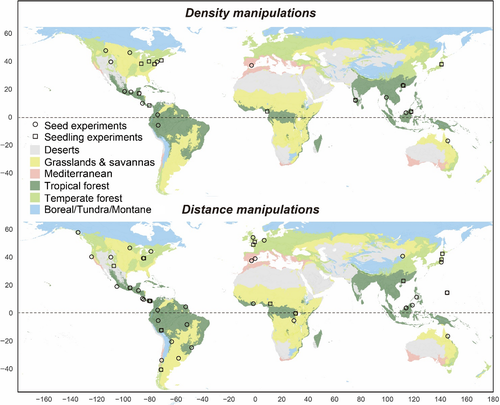

**Figure 1**

Geographical distribution of studies testing density-dependent and distance-dependent J-C effects included in this meta-analysis. [Correction added on 20 January 2021, after first online publication: legend has been modified.]

### Testing for taxonomically-conserved Janzen–Connell effects

Phylogenetic co-variance may inflate effect sizes in comparative studies, especially when estimating community-level effects (Chamberlain *et al*., 2012; Nakagawa and Santos, 2012; Maddison and FitzJohn, 2015). As plant chemical and physical defences may be strongly shaped by evolutionary history (Cavender-Bares *et al*., 2009; Sedio and Ostling, 2013; Coley and Kursar, 2014; Turcotte *et al*., 2014), closely related species or independent measures of the same species do not represent independent data points. In the most comprehensive meta-analysis of J-C effects at the time, C2014 found strong support for both negative distance and density dependence when combing all species and both seed and seedling experiments and concluded that J-C effects are pervasive. We re-evaluate the overall magnitude of distance- and density-dependent effects without including taxonomic random effects, to remain consistent with the C2014 study, and compare this to models including taxonomic random effects to control for potential taxonomic pseudoreplication.

### Meta-analysis

To evaluate the magnitude of distance and density dependence effects across studies, we conducted a meta-analysis using the rma.mv() function of the metafor package version 2.1-0 (Viechtbauer et al. 2010; Viechtbauer 2019). For all of our meta-analysis regressions (meta-regressions), we included the experiment effect size as the response variable and we present the effect sizes from meta-regression models that weight results by the sampling variance. First, we evaluated if the variation in distance and density dependence was taxonomically conserved by including these species, genus and family as random effects and assessing model fit using model selection, wherein smaller Akaike Information Criterion (AIC) values indicate improved model fit. We then selected the model with random effect structure with the lowest AIC (Table 1) for all other mixed-model analyses. We also present standardised effect sizes for each family by including family as a fixed-effect categorical variable. Second, to estimate distance- and density-dependence, we ran meta-regressions without taxonomic random effect (following C2014) and then we compare this to mixed-models that accounted for shared responses among related species by including taxonomic random effects. The mixed-model random effects were included to account for the influence of ‘taxonomic bias’, or overrepresentation of data from a few related species, and pseudoreplication, or sample size inflation due to considering related multiple studies of the same species as independent. Third, we assessed if distance and density dependence varied between the four categories of manipulations (seed versus seedlings and density versus distance – hereafter these four categories are called treatment or manipulation ‘categories’) using model selection. Since there was strong support for evaluating distance and density dependence separately among four treatment categories (Table S1), we subsetted the data accordingly and present results for each category. We also tested if distance and density dependence varied within each treatment category for trees vs non-trees, and temperate vs tropical trees. Finally, we assessed support for adding four covariates previously predicted to mediate J-C effects and distance- and density-dependence (study duration, latitude and rainfall), as well as the treatment intensity of each study (i.e. the factor by which density/closeness to adult was increased relative to controls).

Table 1. Model fit of meta-analytic models with nested taxonomic random effects. The Akaike Information Criterion (AIC) provides a means of model selection, with lower numbers indicating better models. The top row in the table shows the base model without any phylogenetic random effects, and the subsequent lines show models with different types of phylogenetic random effects. There were 47 families and 66.0% of families had multiple observations. There were 114 genera and 45.6% had multiple observations. There were 143 species and 42.0% had multiple observations. [Correction added on 20 January 2021, after first online publication: table 1 has been modified.]

| Random effects | df | AIC |
| --- | --- | --- |
| *~ no random effects~* | *1* | *4049*.*5* |
| **~ 1 \| Species** | **2** | **1909.1** |
| ~ 1 \| Genus / Species | 3 | 1910.1 |
| ~ 1 \| Family / Species | 3 | 1910.6 |
| ~ 1 \| Family / Genus / Species | 4 | 1912.1 |
| ~ 1 \| Genus | 2 | 2126.2 |
| ~ 1 \| Family / Genus | 3 | 2128.2 |
| ~ 1 \| Family | 2 | 2840.1 |

## Results

### Taxonomic effects

First, we tested if conspecific negative distance or density dependence (CNDDD) were conserved within phylogenetic family, genus or species. Relative to a null model without taxonomic random effects, including family, genus and species as random effects significantly improved fits by ΔAIC of −1209.4, −1923.2 and −2140.3 respectively (lower AIC denotes better model fit). A species random effect had the best fit but including nested random effects with species and higher taxonomic levels gave rise to larger AIC values, suggesting that most of the variation in CNDDD occurred between species and was not explained by higher taxonomic ranks (Table 1). Mean effect sizes within each family were highly variable and did not suggest that density or distance dependence are more common than positive or neutral effects (Fig. 2). When analysing all types of manipulations combined, where a significant negative coefficient implies a CNDDD effect, 16 families showed positive responses (*P* < 0.05 for three families) contrary to expectations of CNDDD, whereas 22 showed negative effects consistent with CNDDD (two with *P* < 0.05). When grouping all types of manipulations and taking the mean standardised effect size per species, 38.5% of species showed positive responses to being higher densities/ closer to parents (Fig. 3).

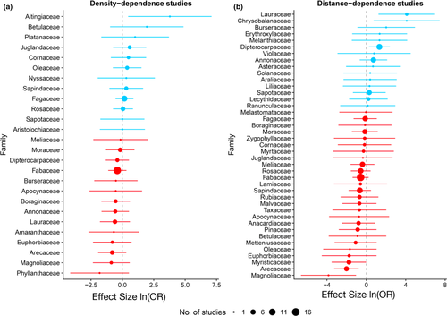

**Figure 2**

Family-level density dependence (a) and distance dependence (b) in plant mortality. Effect sizes (points) were estimated using mixed effect models with a species random effect. Error bars represent 95% confidence intervals. Negative values (red) indicate higher mortality in ‘more dense’ or ‘nearer’ treatments relative to the control (i.e. negative density / distance dependent mortality), whereas positive values (blue) indicate higher mortality of seeds or seedlings in ‘less dense’ or ‘far’ treatments from parent trees relative to the control (i.e. positive density / distance-dependent mortality). Sizes of points are proportional to the number of studies available for that family. Sample sizes per treatment category presented in Fig. S3.

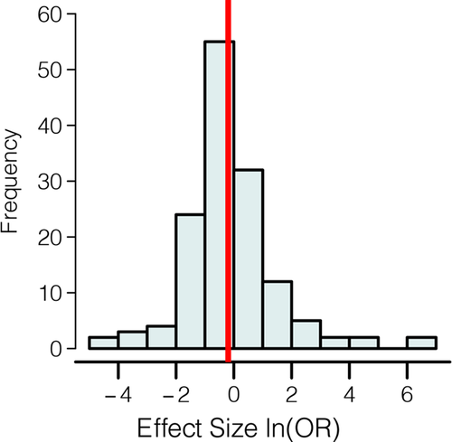

**Figure 3**

Histogram summarising CNDDD responses for 143 species, with each species value averaged among all studies and all manipulation types. The red line shows overall standardised effect size from the meta-analysis controlling for phylogenetics with a species-level random effect [ln(OR) or ‘z’ = −0.194, *P* = 0.055]. The were 61.5% of species showing negative values that would provide support for J-C effects operating, although fewer of these species-level results were significant (Fig. S1).

### CNDDD without controlling for taxonomic pseudoreplication

To mirror previous meta-analyses (Hyatt *et al*., 2003; Comita *et al*., 2014) using our updated data set, we first tested for CNDDD without including species-level random effects. We evaluated if there was an overall global signal of CNDDD and if this varied for density versus distance experiments or seed versus seedling experiments. Without taxonomic random effects, there was a strong overall J-C effect (standardised effect size on mortality, measured in log odds ratios and hereafter called ‘z’ = −0.417; *P* < 0.001), in line with the results of C2014, and when density and distance manipulations were analysed separately (z<sub>density</sub> = −0.370, *P* < 0.001; z<sub>distance</sub> = −0.432, *P* < 0.001). Likewise, there were significant CNDDD when seed and seedling experiments were analysed separately (z<sub>seed</sub> = −0.326, p < 0.001; z<sub>seedling</sub> −0.821, *P* < 0.001). We found no publication bias using funnel plot analysis (Kendall’s rank correlation test of asymmetry: tau = −0.023, *P* = 0.603; Fig. S4).

### J-C effects while controlling for pseudoreplication using species-level random effects

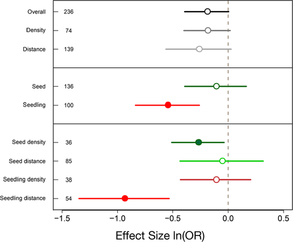

**Figure 4**

Conspecific distance- and density-dependent effects on seed and seedling mortality. Negative coefficients indicate negative density and/or distance-dependent mortality, assessed using a mixed-models with a species random effect. Separate models were fit to estimate each effect, error bars represent 95% confidence intervals and solid points indicate statistically significant effects (95% confidence interval does not overlap zero). Sample sizes for each model are indicated along the y-axis.

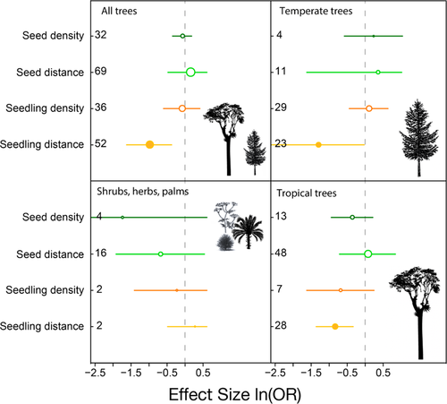

**Figure 5**

Density- and distance-dependent seed and seedling mortality for different life forms and tropical versus temperate trees. Effect sizes were estimated using meta-regression models with a ‘species’ taxonomic random effect. Points show standardized effect size across studies for different treatment types and error bars indicate 95% confidence intervals. Significant effects (*P* < 0.05) are shown as filled-in points. Size of points are scaled to sample size (shown as numbers on the left of each panel). Negative effect sizes indicate that mortality was higher in the denser / closer experimental treatment, consistent with J-C hypotheses. Within each of the four treatment categories, there were no significant differences between trees and non-trees, or between tropical versus temperate tree studies. Non-tree results for temperate versus tropical studies are not shown because most sample sizes were too small (*N* < 5) to provide meaningful tests.

### Mediating covariates (study duration, treatment intensity, latitude and rainfall)

We hypothesised that longer studies and those applying stronger experimental treatment intensities (i.e. closer to parent trees, higher offspring densities) would yield stronger CNDDD results and including the covariates would improve model fit, but this effect was small (Table S2). Longer studies generally show stronger CNDDD (standardised coefficient = −0.858, *P* < 0.001). When treatment types were tested separately, seed density (standardised coefficient = −0.561, *P* < 0.001) and seed distance (standardised coefficient = −0.595, *P* = 0.011) manipulations showed stronger effects with experimental duration. Seedling density showed a positive relationship with duration (standardised coefficient = 0.705, *P* = 0.024) and seedling distance was not significantly mediated by duration (Fig. S5). Treatment intensity also had a significant negative effect when grouping all four manipulation categories (standardised coefficient = −0.365, *P* < 0.001). However, when each type of manipulation was tested separately, treatment intensity did not have a significant mediating effect, suggesting that – given there was higher mortality in treatments than controls – the effect size was not related to the degree to which treatments increased offspring densities or the distances offspring were moved parents (Fig. S6). The exception was that treatment intensity actually reduced seedling distance dependence (standardised coefficient = 0.366, *P* = 0.034; Fig. S6). This means that further treatment distances experienced less distance-dependent mortality than closer treatments (but still more than controls).

The inclusion of latitude and rainfall as additive or interaction with treatment category did not improve model fit (Table S1) and neither latitude nor rainfall were correlated with effect size (latitude coefficient = −0.002, *P* = 0.650; rainfall coefficient = 0.016, *P* = 0.966). When the effect of latitude was tested for each treatment category separately, the results were idiosyncratic with no significant relationship for seed density (*P* = 0.688), seed distance (*P* = 0.295), or seedling distance (*P* = 0.870) and seedling density had a positive relationship (*P* = 0.007; Fig. S7). However, we note that the seedling density result was skewed by having only 7 of 38 data points coming from tropics, and the effect of latitude on seedling density within the temperate region (31 data points) was not significant (coefficient = 0.049, *P* = 0.109). When the effect of rainfall was tested for each treatment category separately, the results were again idiosyncratic with no significant relationship for seed density (*P* = 0.681), negative relationships for seed distance (*P* = 0.071) and a negative relationship for seedling density (*P* = 0.011) and a weak positive relationship for seedling distance (P = 0.067; Fig. S8).

## Discussion

### CNDDD in seeds and seedlings

The implications of weaker CNDDD overall and non-significant effects for many species are profound since there is a significant and growing body of work on plant coexistence being motivated by CNDDD during plant recruitment and J-C effects specifically (e.g. Stump & Chesson 2017; Levi *et al*., 2019; Chisholm and Fung, 2020; May *et al*., 2020). These findings also have important implications for a growing body of applied work on how dispersal limitation could affect tree demography and carbon storage (e.g. in hunted forests; Peres *et al.* 2016, Osuri *et al*. 2016; Cordonnier *et al*., 2018), which often relies on the assumptions of strong CNDDD. While our results show that CNDDD is weaker than previously appreciated, J-C effects may still shape tree composition because a cohort of undispersed seeds can face weak seed density dependence and strong seedling distance-dependence. While changes to CNDDD may influence coexistence, Stump and Chesson (2015) suggest dispersal-limited specialist predators have a weaker effect on coexistence relative to highly dispersed specialists that impose community-level density dependence.

### Strong distance-dependent seedling mortality

A key objective of our synthesis was unravelling how CNDDD varies between seeds and seedlings. Distance had a strong effect on seedling mortality (but not seed mortality) supporting our hypothesis that parents serve as persistent reservoirs for enemies that focus on vegetative tissues (leaves, wood and roots) that are usually available in both young and mature plants. Distance-responsive seedling enemies may include fungal pathogens, sap-feeding insects, or generalised invertebrate herbivores (e.g. chewers; Forrister *et al*., 2019), but the relative importance of different causal agents in distance-dependent mortality remains unclear (e.g. Mangan et al. 2010 and Gripenberg 2014). A recent meta-analysis has specifically assessed the contribution of fungi, insects and vertebrates enemies (Song and Corlett, 2020) found soil pathogens were a major cause of both distance- and density-dependent mortality at the seedling stage, and soil pathogens are often poorly dispersed (Pu and Jin, 2018, Lu *et al*. 2020). As dispersal distance increases, there may be a trade-off between the positive effects of potentially lower enemy loads and the negative effects from being further from the beneficial microhabitat conditions where the parent plant was located (e.g. soil, hydrology, ectomycorrhizal fungi; Comita and Hubbell, 2009, Johnson et al., 2017, Segnitz *et al*., 2020, Xu *et al*., 2020). Thus, the net strength of distance-dependence in tree seedlings suggests that the effect of distance responsive enemies probably outweighs the benefits of settling close to the parent plant during these vulnerable years.

### Weak density-dependent seed mortality

The strong support we observed for distance-dependent mortality among seedlings – but not seeds – suggests parent trees are rarely important reservoirs of seed enemies. Furthermore, we only found weak support for density-dependent mortality among seeds and not seedlings, suggesting some mobile seed enemies are attracted to aggregations of seeds. Poorly dispersed seeds are often clustered below their parent plants or aggregated in wildlife nesting or roosting sites where many seeds are defecated or regurgitated (‘contagious seed dispersal’; Schupp *et al*., 2002; Wright *et al*. 2016). Such seed clumps may be easy targets because they attract both specialist and generalist seed predators, inducing density-dependence (Hulme, 1998). The J-C hypothesis has traditionally focused on host-specific invertebrate seed predators that are more specialised than other feeding guilds (Janzen 1980, Ctvrtecka *et al*. 2014, but see Sam et al. 2017). However, generalist invertebrate or vertebrate seed predators are also attracted to dense fruit or seed crops, whether those be monocultures or mixed species clumps, and whether they are clumped nearby the parent plant or further away (Hulme, 1998). The high mobility of these density-responsive specialists and generalist vertebrate and invertebrate seed enemies may also explain why distance from parent tree was not consequential for seeds in our study.

There are some caveats with regards to weak CNDDD effects in seeds, such as significance being driven by few outliers within in the palms. The methods used to quantify survival may also suffer bias against detecting J-C effects. For instance, survival rate may be overestimated in studies counting the number of seeds that persisted if they did not wait to measure germination rates since remaining seeds could still be affected by cryptic insects or fungus. We were also unable to assess if smaller seeds suffered weaker CNDDD effects than larger seeds, which could be the case if small seeds are better defended than large seeds (Paine and Beck, 2007; Fricke and Wright, 2016; Lebrija-Trejos *et al*., 2016).

### Idiosyncratic effects among mediating covariates

Identifying the characteristics of studies and species that show strong CNDDD may yield important breakthroughs, although our assessment did not provide clear relationships. An intuitive expectation is that any J-C effects would increase with longer study duration and/or treatment intensity because it provides more time for deaths to occur and increase the underlying treatment effect respectively. We only found larger J-C effects when grouping all duration and/or treatment intensity treatment categories, and we did not observe a consistent patterns within each treatment category (Fig. S5 & S6). In fact, some categories even showed positive relationships with duration and/or treatment intensity suggesting less J-C effects in shorter studies or less extreme treatments). High variation in species responses and context-specificity may have masked the effects of duration and treatment. Distance manipulations may have failed to detect an effect of the treatment intensity because J-C effects rely on the relative dispersal distances of seeds versus their natural enemies (Adler & Muller-Landau *et al*., 2005; Beckman *et al*., 2012), which varies across species (e.g. a 50-m distance treatment may be important for plants with poorly dispersed enemies but not plants with highly mobile enemies).

### Far from settled

There is a notable gap in community-level analyses that aim to determine the traits of seeds and seedlings that make them susceptible to J-C effects. Another issue is that rare species are often missing in experimental studies due to difficulties obtaining sufficient sample sizes, so inferences presented here are generally limited to relatively common species. If rarer species have stronger CNDDD than common species, as suggested by some authors (Comita *et al*., 2010, Marden et al., 2017, Stump et al. 2020; but see Detto *et al*., 2019), and rare species have been avoided in CNDDD experiments, then our synthesis may underestimate the global-importance of J-C effects. There is also less work on the J-C effects at the pre-dispersal seed stage, where bruchid, curculionid and scolytid beetles, hemipterans, lepidopteran and dipteran larvae may be important, and this constrains our inference about J-C effects throughout the seed period (Gripenberg, 2018; Basset *et al*., 2019). Finally, there are few experiments that can differentiate mortality from specialist versus generalist enemies (Song & Corlett 2000) or differentiate mortality from enemies versus competition (Adler *et al*., 2018) or other sources (Rosin *et al*., 2017). These gaps suggest current experimental work on the J-C hypothesis, although more robust than observational studies (Detto *et al*., 2019), remains inadequate for drawing robust conclusions about the role of enemies on plant populations. Future work should strive to narrowly define hypotheses about specific host-enemy relationships, place more emphasis on the plant species chosen in experiments (including rare species), carefully consider the study plants’ traits, and the ecologies of their enemies (including dispersal abilities), try to attribute mortality to specific enemies, and control the experimental context including abiotic conditions and soils (Crawford *et al*., 2019; Jia *et al*., 2020; Xu *et al*., 2020).

Despite the J-C hypothesis turning 50 years old this year, the state of science is far from settled, and there remains plenty of room for important works to contribute to this field. In the meantime, our findings suggest J-C effects may not be as large or pervasive as widely thought and not generalisable across life stages. Nonetheless, there are strong effects of seedling distance-dependence in trees and this may contribute to forest spatial dynamics, local diversity and coexistence.

## Acknowledgements

This research was supported by the Strategic Priority Research Program of the Chinese Academy of Sciences (XDB31000000), the National Natural Science Foundation of China (31800353), the West Light Foundation of Chinese Academy of Sciences and the CAS 135 program (No. 2017XTBG-T01). XS, JY and MSL acknowledge the Smithsonian Institution’s ForestGEO annual workshops for funding support and facilitating this research. M. Visser and L. Hulsman provided input on statistics and comments provided by S. Hart, three anonymous reviewers, R. Chisholm and his laboratory group, and the Ecological Cascades Lab at the University of Queensland improved earlier drafts of this manuscript.

## Authorship

XS, MSL and JYL designed the study, XS collected the data and MSL and XS analysed the data. MSL and JYL wrote the paper and all authors contributed to the final version.

# Peer Review

The peer review history for this article is available at https://publons.com/publon/10.1111/ele.13665.

# Open Research Badges

This article has earned Open Data and Open Materials badges. Data and materials are available at https://datadryad.org/stash/dataset/doi:10.5061/dryad.91ht938?

# Data Availability Statement

The data and R code are available via the Dryad Digital Repository https://datadryad.org/stash/dataset/doi:10.5061/dryad.91ht938?

## Supporting Information

| Filename | Description |
| --- | --- |
| ele13665-sup-0001-Supinfo.Rtext/r-script, 8.8 KB | Supplementary Material |
| ele13665-sup-0002-Supinfo.docxWord document, 1.3 MB | Supplementary Material |
| ele13665-sup-0003-Supinfo.csvapplication/csv, 65.2 KB | Supplementary Material |

Please note: The publisher is not responsible for the content or functionality of any supporting information supplied by the authors. Any queries (other than missing content) should be directed to the corresponding author for the article.

## Citing Literature

[figure not shown]

[Volume24, Issue3](https://onlinelibrary.wiley.com/toc/14610248/2021/24/3)

March 2021

Pages 608-620

### Metrics

Citations: 3

### Details

© 2020 John Wiley & Sons Ltd.

### Research funding

- National Natural Science Foundation of China. Grant Numbers: 31800353, 2017XTBG-T01
- Chinese Academy of Sciences
- Smithsonian Institution
- University of Queensland

### Keywords

- [Density dependence](https://onlinelibrary.wiley.com/action/doSearch?field1=Keyword&text1=Density%20dependence)
- [distance dependence](https://onlinelibrary.wiley.com/action/doSearch?field1=Keyword&text1=distance%20dependence)
- experiments
- herbivory
- [host-specific enemies](https://onlinelibrary.wiley.com/action/doSearch?field1=Keyword&text1=host%E2%80%90specific%20enemies)
- [plant mortality](https://onlinelibrary.wiley.com/action/doSearch?field1=Keyword&text1=plant%20mortality)
- [plant recruitment](https://onlinelibrary.wiley.com/action/doSearch?field1=Keyword&text1=plant%20recruitment)
- [plant–animal interactions](https://onlinelibrary.wiley.com/action/doSearch?field1=Keyword&text1=plant%E2%80%93animal%20interactions)
- [seed dispersal](https://onlinelibrary.wiley.com/action/doSearch?field1=Keyword&text1=seed%20dispersal)
- [seed predation](https://onlinelibrary.wiley.com/action/doSearch?field1=Keyword&text1=seed%20predation)

### Publication History

- Issue Online: 12 February 2021
- Version of Record online: 31 December 2020
- Manuscript accepted: 25 November 2020
- Manuscript revised: 18 August 2020
- Manuscript received: 06 July 2020